# So Many Species, So Little Time: Calculating and Visualizing Biodiversity

Learn to understand what biodiversity means, how to quantify and compare it using metrics such as Shannon-Weiner and Simpson’s indexes, and visualize it using Rank-Abundance Curves.

Jory Griffith , Egor Katkov , Maggie Slein  
2022-08-26

# Tutorial Overview

Biodiversity is a hot topic in the fact of unprecedented global change in the 21st century. With a publicly available dataset, [from the Turkey Lakes Watershed in Ontario, Canada](https://open.canada.ca/data/en/dataset/f9e1595d-27bb-4a6a-b94d-6b9bed7db263), we demonstrate how to quantify biodiversity quantitatively and visually using `R`.

# Learning objectives

Using historical data from a freshwater lake ecosystem, by the end of this tutorial you will be able to:

1. Identify, calculate, and implement commonly used metrics to quantify biodiversity
2. Understand and create figures uses to display biodiversity data
3. Analyze the change in biodiversity of benthic invertebrates over multiple disturbance levels and years

```r
library(leaflet)

prefix = 'https://api.gbif.org/v2/map/occurrence/density/{z}/{x}/{y}@1x.png?'
style = 'style=purpleYellow.point'
tile = paste0(prefix,style)

leaflet() %>%
setView(lng = 20, lat = 20, zoom = 01) %>%
addTiles() %>%
addTiles(urlTemplate=tile)
```

[interactive chart not shown]

Figure 1: Occurrences of species across the globe from the Global Biodiversity Information Facility (GBIF.org 2022).

Ecologists are often interested in the effects of perturbations (e.g. disturbances like fires, logging, flooding or pollution) on biodiversity, which can yield information and context for ecosystem health. However, boiling biodiversity down to a single metric can be difficult and incomplete depending on the goal. With the help of the Turkey lake dataset of benthic invertebrates, we will present you with a number of common metrics to assess biodiversity, their meaning, and how they can be visualized with the help of Rank-Abundance curves. First, we will teach you how to calculate these metrics using equations and abundance data, and then we will teach you how to use the `codyn` package to calculate these biodiversity metrics quickly and easily.

You will then have the option to learn to calculate biodiversity metrics yourself using an R package called codyn.

# Why biodiversity matters

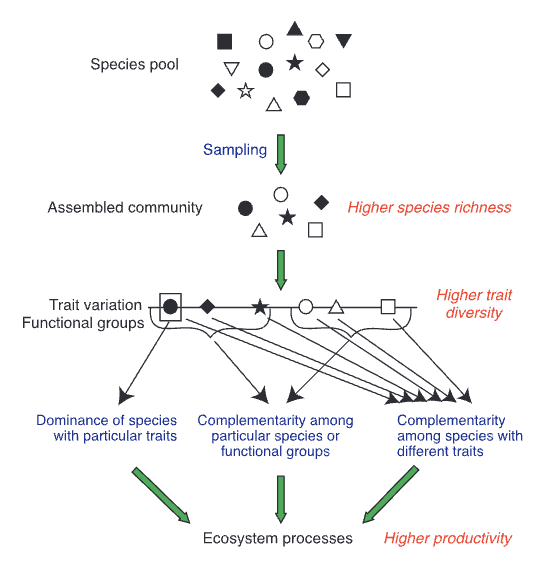

Figure 2: Importance of biodiversity for downstream effects on ecosystem success, structure, and function. Reproduced from (Loreau et al. 2001).

```r
knitr::include_graphics("biodiv_scheme.png")
```

In an ever-changing world, we are often concerned with how organisms will be able to cope with disturbances and increasingly, global climate change. Biodiversity is the variety of life at all levels, from genes to ecosystems. Not only is biodiversity important for ecosystems to function properly, it is also an important buffer to withstanding changing environments. When there is high biodiversity, there is a higher chance of some organisms surviving ecosystems that are changing due to disturbance or climate change. Biodiversity therefore increases the resiliency of these ecosystems and the likelihood that they will be able to persist beyond this change.

# Types of data typically collected

Biodiversity is a broad term, and can be difficult to quantify. Biologists have created several standard measures of biodiversity that convey different information about ecosystems and the species living there.

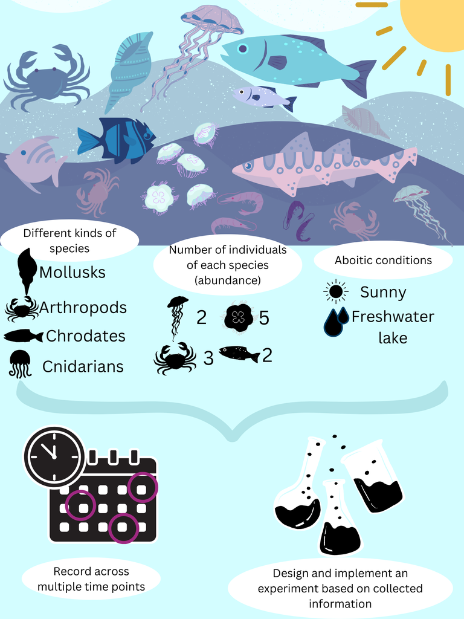

Figure 3: Schematic of freshwater lake ecosystem demonstrating the different information biologists to collect to understand biodiversity

```r
knitr::include_graphics("species_scheme.png")
```

Often times, biologists interested in collecting biodiversity data collect a standard set of responses. These often include:

1. The different kinds of species in a given area or environment
2. The number of individuals of each species (abundance)
3. Information about the area itself (i.e. habitat type, weather conditions, etc.)
4. If the work involves an setting up an experiment, collecting the control vs. experimental groups as well as metrics for replication and statistical power
5. The time frame over which the data were collected

# Real-world biodiversity data

The Turkey Lakes watershed is located in Ontario, Canada, approximately 50 km north of Sault Ste. Marie. It is 10 km<sup>2</sup> in area and contains a chain of 4 lakes. The Turkey Lakes Watershed Study (see map) is an initiative by several agencies of the government of Canada, initially designed to study the effects of acid rain on forest ecosystems. From 1995 to 2009, scientists collected, identified and counted benthic invertebrates from various stream beds around the Turkey Lakes catchment.

```r
pacman::p_load(leaflet)

leaflet() %>%
  addTiles() %>%  # Add default OpenStreetMap map tiles
  addMarkers(lng=-84.4110, lat=47.0515, popup="Turkey Lakes") %>%
  setView(lng=-84.4110, lat=47.0515, zoom=2)
```

[interactive chart not shown]

Figure 4: Interactive map of the Turkey Lakes study site

Benthic invertebrates are small, often microscopic organisms (see Fig. 5), but form an important link between aquatic and terrestrial habitats. They can decompose terrestrial matter such as leaves, or consume periphyton (algae and cyanobacteria) growing on rocks within their streams. Benthic invertebrates can be a food source for aquatic animals, like small fish, or terrestrial animals such as birds. An experiment was conducted in 1997 where certain sampling sites experienced different levels of logging intensity. Due to their interaction with the terrestrial realm, we can hypothesize that the biodiversity of benthic invertebrate communities might be affected by logging.

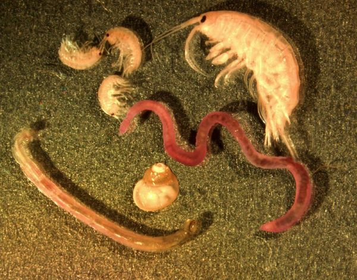

Figure 5: Various benthic macroinvertebrates under a stereo microscope (EPA 2022)

```r
knitr::include_graphics("benthicmacroinvertebrates_g.carter_noaa600px.jpg")
```

## Downloading and tidying the data

The data “TWL_invertebrateDensity.csv” from the [Government of Canada “Open Government” Portal on the “Turkey Lakes Watershed” page](https://open.canada.ca/data/dataset/576f1b52-3fce-497e-8e4c-0899acfdca1f) can be downloaded and saved as a `data.frame` object using the `read.csv` function. We can take a look at the data using the `head()` function.

```r
df.read <- read.csv(file="https://ftp.maps.canada.ca/pub//nrcan_rncan/Forests_Foret/TLW/TLW_invertebrateDensity.csv")
head(df.read) # take a look at the data
```

```
  catchment year month replicate Aeshna Alloperla  Ameletus
1        33 2001   may         1     NA         0 24.242424
2        33 2001   may         2     NA         0 24.242424
3        33 2001   may         3     NA         0 21.212121
4        33 2001   may         4     NA         0 12.121212
5        33 2001   may         5     NA         0  0.000000
6        33 2001   may         6     NA         0  9.090909
  Amphinemura  Antocha   Baetis Boyeria Centroptilum Ceratopogonidae
1          NA 0.000000 0.000000      NA           NA        0.000000
2          NA 0.000000 3.030303      NA           NA        6.060606
3          NA 0.000000 3.030303      NA           NA       27.272727
4          NA 3.030303 6.060606      NA           NA       12.121212
5          NA 0.000000 3.030303      NA           NA       12.121212
6          NA 0.000000 3.030303      NA           NA        3.030303
  Chelifera Cheumatopsyche Chironomidae Chloroperlidae Chloroperlinae
```

[output cut: 111 more lines]

First, in order to quantify biodiversity, we will convert the species densities reported in the dataset to the raw counts (i.e. abundances) to obtain whole numbers of individuals. To do this, it is helpful to transform the “wide” format `data.frame` (where each species is a column) to “long” format, where species names are all found in a single column using the `tidyr::pivot_longer()` function.

```r
library(dplyr)
df.count <-
  df.read %>%
  # Convert from wide to long format to simplify the operation
  tidyr::pivot_longer(
    "Aeshna":"Trichoptera",
    names_to = "Species",
    values_to = "Density" ) %>%
  mutate(
    # Densities to counts
    Count = Density * 0.33,
    Count = tidyr::replace_na(Count, 0) # Replace NAs with 0.
    )
```

# Quantifying biodiversity with real data

# Metrics of Biodiversity

There are several different ways to analyse and understand changes in community composition, or the relative abundances of all taxa in a community. Each of these metrics allow us to look at different aspects of the biodiversity data we collect (MacDonald, Nielsen, and Acorn 2016).

Click through the tabs to learn how to calculate these different measures of biodiversity.

## *Species richness*

Perhaps the simplest measure of biodiversity is species richness ($S$).

The equation for species richness is:

$S = \sum_{i=1}^{S}p_i^o$

$p_i^o$ represents the proportion of individuals of species $i$, taking the sum across each of these species

**Step 1:** Count the number of unique species recorded in that year. Then you can look at how the number of different species in a community changes over time.

**Interpretation:** A higher number means there are more species, and therefore species richness is higher.

```r
#loading necessary libraries
pacman::p_load(kableExtra)
richness_table <- df.count %>%
  # Avoid counting species that had zero observations
  filter(Count > 0,
         year %in% c(1995, 1997, 2001, 2009)) %>%
  group_by(year) %>%
  summarise(richness=length(unique(Species)),
            # Check how many catchments were sampled in each year
            catchments = length(unique(catchment)))
#Nice looking kable
kable(richness_table, col.names=c("Year", "Richness", "Catchments Sampled"), align="c")%>%
  kable_classic(full_width = F, html_font = "Cambria")
```

| Year | Richness | Catchments Sampled |
| --- | --- | --- |
| 1995 | 48 | 6 |
| 1997 | 51 | 9 |
| 2001 | 65 | 9 |
| 2009 | 50 | 3 |

We can see in this table that across years, the number of species in the same area fluctuated. However, this metric is particularly sensitive to changes in sampling efforts because additional sampling is likely to uncover additional, rare species. As a result, the only reliable comparison is between 1997 and 2001, which suggests that species richness increased following the logging operations of 1997. However, this does not tell us anything about how the abundances of different species changed.

## Shannon-Wiener Index (H’)

Another metric we can use to analyze biodiversity is the Shannon-Wiener Index ($H$), which indexes across the sum of all relative proportions of species richness’s with an additional logarithmic transformation. This equation takes into account both the number of species in a specific area (richness) and relative abundances (evenness).

The equation for the Shannon-Weiner Index is:

$$H' = - \sum_{i=1}^{S}p_i~\ln(p_i)$$

$$p_i = n_i/N$$

Where $n_i$ is the number of individuals of species $i$ and $N$ is the total number of individuals in the community.

**Step 2:** Multiply the proportion of each species ($p_i$) by the natural logarithm of the proportion ($\ln(p_i)$)

**Step 3:** Sum each of these values for each species.

**Step 4:** Multiply the sum by -1.

**Interpretation:** The minimum value of the Shannon’s diversity index is 0, which means that there is no diversity (i.e. only one species is found in that habitat). The values increase as the number of species increase, and is maximized at a given number of species when is an equal abundance of each species.

```r
shannon <-
  df.count %>%
  filter(year %in% c(1995, 1997, 2001, 2009)) %>%
  # Summarise over catchments and replicate sites
  group_by(year, Species) %>%
  summarise(TotalCount=sum(Count)) %>%
  mutate(
    # Step 1
    # Note that sum(TotalCounts) calculates the "N"
    # for each year separately because the data.frame
    # was previously grouped by year using the
    # function group_by().
    pi = TotalCount/sum(TotalCount),
    # Step 2
    pi_ln_pi = pi*log(pi)) %>%
  # Steps 3 & 4.
  # Note that na.rm = T because for species abundances = 0,
  # p_i * log(p_i) = 0 * -Inf = NaN
  summarise(shannon = -1*sum(pi_ln_pi, na.rm=T))

kable(shannon, col.names=c("Year", "Shannon's Index"), align="c")%>%
  kable_classic(full_width = F, html_font = "Cambria")
```

| Year | Shannon’s Index |
| --- | --- |
| 1995 | 2.407170 |
| 1997 | 2.081374 |
| 2001 | 2.448311 |
| 2009 | 2.540719 |

We can see that the Shannon diversity changes over time, with the lowest value being the year of the forest harvesting operations (1997). However, it seems that biodiversity quickly recovers in the years following the harvesting.

## Simpson’s Index (D)

Another metric we can use to analyse biodiversity in the Simpson’s index ($D$) which indexes across the sum of all relative proportions of species’s richness with an additional square power transformation. Though very similar to the calculation in the Shannon-Wiener Index, the Simpson index is more focused on dominance of species as it highlights the proportion of species in a sample.

The equation for Simpson’s diversity is:

$$D = 1-\sum_{i=1}^{S} \frac {n_i(n_i-1)}{N(N-1)}$$

Where $n_i$ is the number of individuals of species $i$ and $N$ is the total number of individuals in the community.

**Step 1:** Multiply the number of individuals of a given species ($n_i$) by ($n_i-1$).

**Step 2** Multiply the total number of individuals in the community ($N$) by ($N-1$).

**Step 3:** Divide the number from step 1 by the number from step 2.

**Step 4:** Once you have the numbers from step 3 for each species in the community, sum all of these together and substract from 1.

**Interpretation:** The higher the value of $D$, the greater the diversity in the community. An index close to 1 means that there are several species in the community, and the population proportion of species is even. On the other hand, $D=0$ indicates a single-species community

```r
simpson <-  df.count %>%
  filter(year %in% c(1995, 1997, 2001, 2009)) %>%
  # Summarise over catchments and replicate sites
  group_by(year, Species) %>%
  summarise(TotalCount=sum(Count)) %>%
  mutate(
    # Step 1
    num = TotalCount*(TotalCount - 1 ),
    # Step 2 (Note: data.frame grouped by year)
    denom = sum(TotalCount)*(sum(TotalCount)-1),
    # Step 3
    frac = num/denom) %>%
  # Step 4
  summarise(simpson = 1 - sum(frac))

kable(simpson, col.names=c("Year", "Simpson's Index"), align="c")%>%
  kable_classic(full_width = F, html_font = "Cambria")
```

| Year | Simpson’s Index |
| --- | --- |
| 1995 | 0.8372515 |
| 1997 | 0.7452368 |
| 2001 | 0.8423991 |
| 2009 | 0.8757629 |

Similarly to the Shannon-Weiner index, biodiversity dropped in 1997, but had recovered by 2001.

## Evenness Index (E)

Additionally, we can think about the evenness of species across a given area. Evenness is a type of metric for assessing species dominance. If evenness is high, it means most species are of equal dominance. If evenness if low, it means some species are more dominant (i.e. have higher abundance) than others. Evenness is maximized when all species have equal abundances. Multiple metrics can be used to measure evenness, here we show an example of “Shannon-Wiener” evenness, however a similar approach can be used for simpson evenness.

The equation for “Shannon-Wiener” evenness is:

$E = H / ln(S)$

**Interpretation:** Values closer to one signify more evenness and values closer to 0 signify lower evenness.

```r
# Combine previously calculated species richness
#  and shannon index tables
evenness =
  left_join(richness_table, shannon) %>%
  # Step 1
  mutate(evenness = shannon/log(richness)) %>%
  select(year, evenness)

kable(evenness, col.names=c("Year", "Evenness"), align="c")%>%
  kable_classic(full_width = F, html_font = "Cambria")
```

| Year | Evenness |
| --- | --- |
| 1995 | 0.6218149 |
| 1997 | 0.5293657 |
| 2001 | 0.5865078 |
| 2009 | 0.6494644 |

As with previous biodiversity metrics, we find that evenness is lowest in 1997, and recovers in the following years.

# Visualizing Biodiversity

Apart from calculating biodiversity using the metrics above, visualizing differences using graphs is another tool we have. One way to visualize biodiversity data is to make a rank-abundance curve. On the y-axis we have the species (numbered), and on the y axis we have the abundance. The plots are organized from high to low abundance. Using rank-abundance curves, we can visualize the change in relative abundance and species dominance over time.

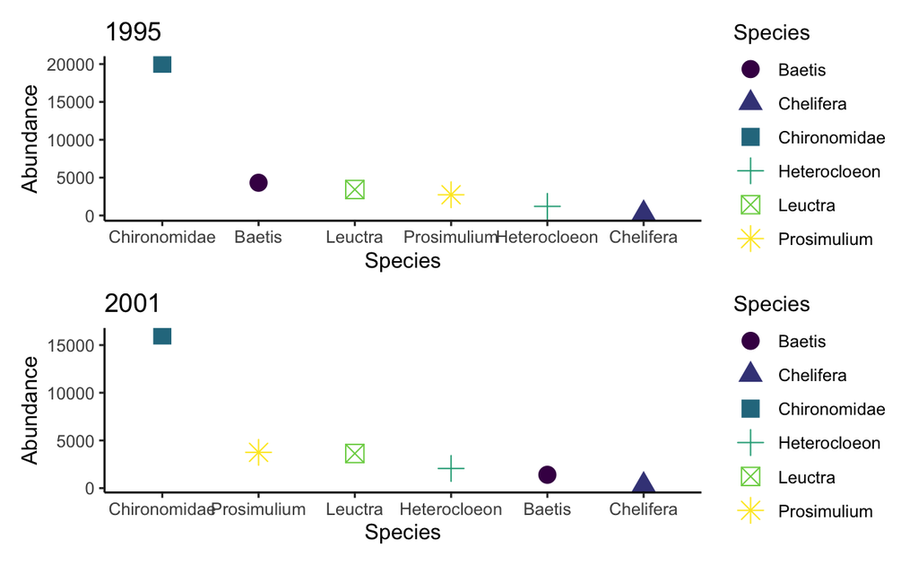

Figure 6: Simple rank-abundance curve with 6 species from the Turkey Lakes dataset, with counts from 1995 and 2001. Colour and shape indicate a unique species, with y axis representing abundance.

```r
#loading necessary libraries
pacman::p_load(tidyverse, patchwork)
#creating a subset of the full data with just 6 species, across 4 years
subset <- df.count %>%
  filter(Species %in% c("Chironomidae", "Prosimulium", "Baetis", "Heterocloeon", "Chelifera", "Leuctra")) %>%
  filter(year %in% c(1995, 1997, 2001, 2009)) %>%
  group_by(year, Species) %>%
  summarise(sum=sum(Count))

#2007
a<- subset %>%
  filter(year==1995) %>%
ggplot(aes(x=reorder(Species, -sum), y=sum, shape=Species, colour=Species))+
  geom_point(size=4)+
  scale_colour_viridis_d()+
  ggtitle("1995")+
  labs(x="Species", y="Abundance")+
  theme_classic()+
  #theme(legend.position="none")+
  labs(x="Species", y="Abundance", color="Species")

#2007
b<- subset %>%
  filter(year==2001) %>%
ggplot(aes(x=reorder(Species, -sum), y=sum, shape=Species, colour=Species))+
  geom_point(size=4)+
  scale_colour_viridis_d()+
  ggtitle("2001")+
  labs(x="Species", y="Abundance")+
  theme_classic()+
  #theme(legend.position="none")+
  labs(x="Species", y="Abundance", color="Species")

a / b
```

## Rank abundance curves with Turkey Lakes invertebrate data

### Additional data wrangling

The dataset spans multiple years, months, and catchments within the Turkey lakes watershed and includes densities for a wide array of invertebrate species across multiple replicate sites. You can visualize Rank Abundances for any subset of the dataset using [the following Shiny App](https://ekatko1.shinyapps.io/TurkeyLakesInverts/).

Using information obtained from the [metadata of this dataset](https://ftp.maps.canada.ca/pub//nrcan_rncan/Forests_Foret/TLW/TLW_invertebrate_metaEN.csv), we can add some interesting details to the data (for at least a few catchments and years). For the purposes of this portion of the tutorial, we also select a different subset of the data to work with.

```r
## Different catchments had different logging intensities
treatment = tibble(catchment =             c("34M",  "34U",    "34L"),
                   `Logging Intensity`   = c("none", "medium", "high"))

## Logging happened in 1997
yearAnnot = tibble(
  year = 1995:2001,
  trt  = c( rep("pre-logging", 2), "logging", rep("post-logging", 4))
)

df.subset =
  df.count %>%
    right_join(treatment) %>%
    right_join(yearAnnot) %>%
  filter(month %in% c("june", "may"))
```

Then, we will clean up the data by removing any species whose count is zero across all the different sites and years.

```r
## Find species that have 0 abundance across all sites and years.
NA_sp = df.subset %>%
  group_by(Species) %>%
  summarize(Count = sum(Count, na.rm=T)) %>%
  filter(Count==0) %>%
  select(Species)

## Remove those species from the dataset
df.clean = df.subset %>%
  anti_join(NA_sp)
```

### Summarise Data

Let’s start by looking at catchment “34L”, which saw high levels of deforestation in June of 1998, the year following the logging event.

```r
df.subset1 <- df.subset %>%
  filter(catchment == "34L",
         year      == 1998,
         month     == "june")
```

Next, we can sum the count data over all the replicate sites within the catchment to obtain a total count within the catchment.

```r
df.raw.summary1 =
  df.subset1 %>%
  group_by(Species) %>%
  summarise(
    TotalCount = sum(Count))
```

Then, we order the species from most abundant to least abundant.

```r
df.ordered.summary1 =
  df.raw.summary1 %>%
  arrange(desc(TotalCount))
```

Finally, we assign a rank to the species (rank 1 = the most abundant species) and filter out any species which are not actually present in this catchment.

```r
df.summary1 =
  df.ordered.summary1 %>%
  mutate( Rank = seq_along(Species) ) %>%
  # Keep only species with abundances greater than zero.
  filter(TotalCount > 0)
```

### Plot the data

We make a plot to represent the data. Note that we need to use the `stats::reorder()` function to get the species on the x-axis in the correct order:

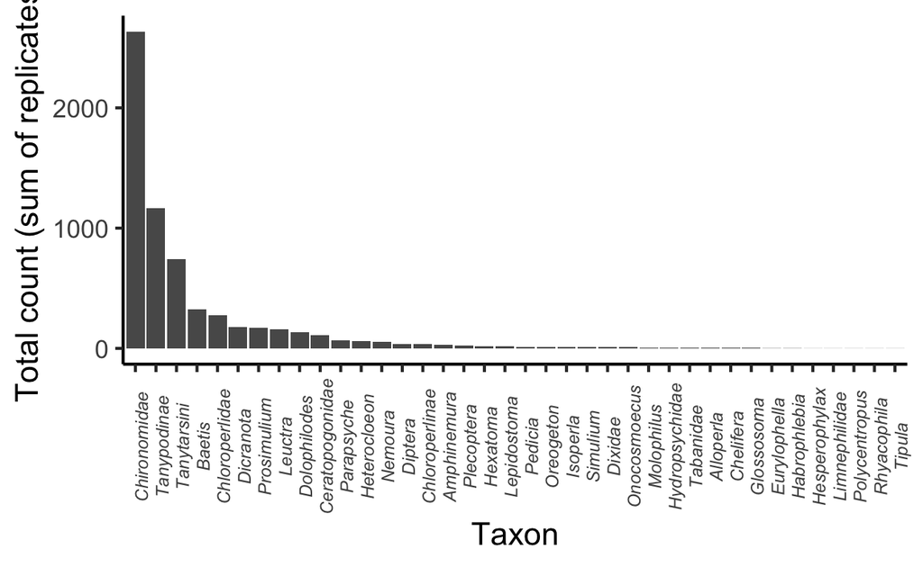

Figure 7: Abundance of species in catchment 34L of the Turkey Lakes in June 1998

```r
library(ggplot2)
plot1 =
  df.summary1 %>%
  ggplot(aes(x=reorder(Species, -1*TotalCount),
             y=TotalCount)) +
  geom_col() +
  xlab("Taxon") +
  ylab("Total count (sum of replicates)") +
  theme_classic(base_size=16) +  # Aesthetic
  theme(axis.text.x = element_text(face="italic", size=9, angle=90)) # Use italics for species names
plot1
```

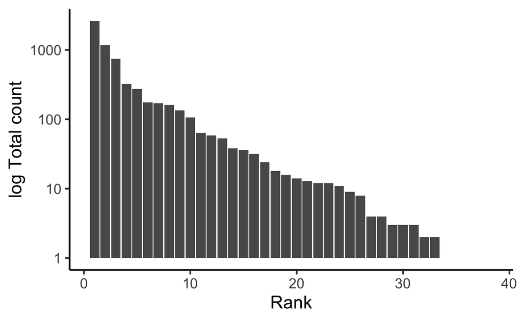

Figure 8: Abundance of species in catchment 34L of the Turkey Lakes in June 1998

```r
df.summary1 %>%
  ggplot(aes(x=Rank, y=TotalCount)) +
  geom_col() +
  xlab("Rank") +
  scale_y_log10() +
  ylab("log Total count") +
  theme_classic(base_size=16) # Aesthetic
```

### Comparing rank-abundance curves

Instead of using bars to represent abundances, we can simply use lines to trace the distribution. This allows us to compare multiple distributions. First, let’s compare the different replicates (i.e., sites) within a single catchment area (34L).

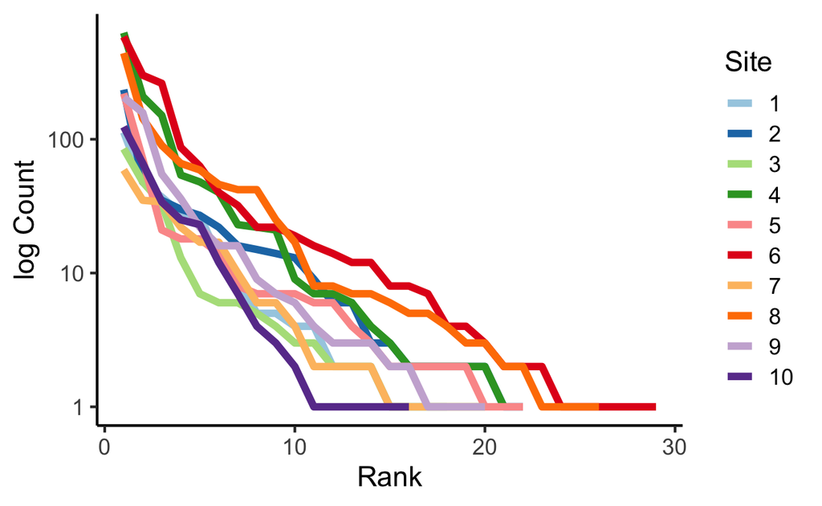

Figure 9: Comparison of rank-abundance curve changes across different sites (replicate)

```r
df.subset1 %>%
  group_by(replicate) %>%
  # Order by rank, for each catchment (.by_group=T)
  arrange(desc(Count), .by_group = T) %>%
  mutate( Rank = seq_along(Species) ) %>%
  # Keep only species with abundances greater than zero.
  filter(Count > 0) %>%
  # Line Plot
  ggplot(aes(x=Rank, y=Count, color=as.factor(replicate))) +
    xlab("Rank") +
    ylab("log Count") +
    geom_line(size=2) +
    scale_y_log10() +
    # Some aesthetic choices:
    theme_classic(base_size=16) +
    scale_color_brewer(name = "Site", palette = "Paired")
```

Alternatively, we can compare rank-abundance curves from three different catchments, each of which has a different logging intensity. Note that all catchments have 10 replicate sites, which allows us to sum across replicates. Also note that differences in sampling can affect the shape of the rank-abundance curves, which means that one has to be careful to account for sampling effort when comparing rank-abundance curves from different studies.

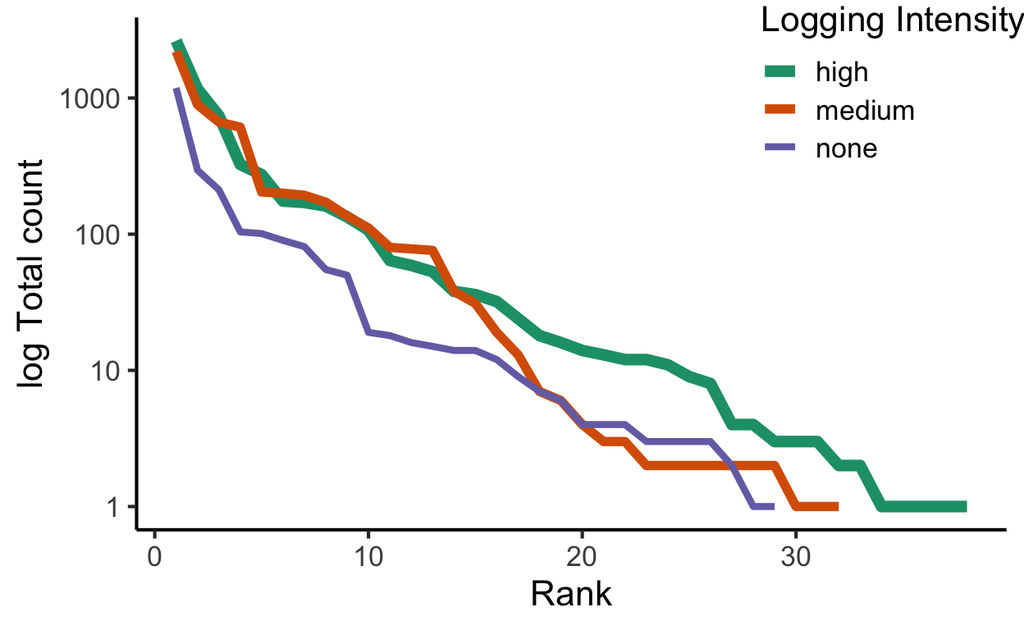

Figure 10: Comparison of rank-abundance curve changes across sites with different logging intensity

```r
plot =
  df.subset %>%
  # Subset
  filter( year      == 1998,
          month     == "june") %>%
  # Summarise across replicates
  group_by(`Logging Intensity`, catchment, Species) %>%
  summarise(TotalCount=sum(Count)) %>%
  # Order by rank, for each catchment (.by_group=T)
  group_by(catchment, `Logging Intensity`) %>%
    arrange(desc(TotalCount), .by_group = T) %>%
    mutate( Rank = seq_along(Species) ) %>%
  # Keep only species with abundances greater than zero.
  filter(TotalCount > 0) %>%
  # Line Plot
  ggplot(aes(x=Rank, y=TotalCount, color=`Logging Intensity`)) +
    xlab("Rank") +
    ylab("log Total count") +
    geom_line(aes(size=`Logging Intensity`)) +
    scale_y_log10() +
    # Some aesthetic choices:
    scale_size_manual(values=c(2.5, 2, 1.5)) +
    theme_classic(base_size=16) +
    scale_color_brewer(palette="Dark2") +
    theme(legend.position = c(0.87,0.87))
plot
```

Notice that we can rapidly see that the catchment with high intensity logging had the highest species richness (highest maximum rank). The catchment that we logged with medium intensity also appears to have a less “even” rank-abundance curve compared to the other two. In other words, the slope is slightly steeper for the “medium” intensity site than for the “high” and “none” (no logging) catchments. Of course, many more sites over several years need to be compared in order to make any generalizable claims about the effects of logging on invertebrate biodiversity in the Turkey Lakes area.

Furthermore, several models have been developed to understand rank-abundance curves (e.g. log-normal, broken stick model). The [`radfit`](https://search.r-project.org/CRAN/refmans/vegan/html/radfit.html) function from the `vegan` `R` package allows fitting of these different curve models (RDocumentation 2022).

# Measure and Visualize Biodiversity with `codyn`

Now that we have calculated different biodiversity metrics and rank abundance curves by hand, we can also use existing functions in the `R` package `codyn` (Hallett et al. 2016) to quantify and visualizing changes in biodiversity with the Turkey Lakes dataset.

## Load Data and Packages

Along with the `codyn` package, we will also use `ggplot2` and `dplyr` for plotting and cleaning. First, we need to load these packages.

```r
library(ggplot2)
library(codyn)
library(dplyr)
```

Load, subset and clean the data (see “Rank abundance curves with Turkey Lakes invertebrate data” above for details) :

```r
data  <-
  read.csv(file="https://ftp.maps.canada.ca/pub//nrcan_rncan/Forests_Foret/TLW/TLW_invertebrateDensity.csv") %>%
  pivot_longer( "Aeshna":"Trichoptera", names_to = "species", values_to = "density") %>%
  mutate(abundance = density * 0.33,
         treatment = case_when(catchment %in% c("33") ~ "low",
                               catchment %in% c("34U") ~ "medium",
                               catchment %in% c("34L") ~ "high",
                               catchment %in% c("34M") ~ "control",
                               TRUE ~ "natural"),
         date_yr_m = zoo::as.yearmon(paste0(year,month), "%Y %b")) %>%
  drop_na(abundance) %>%
  filter(year >= 1995,
         year <= 2001,
         # stringr::str_starts(catchment, stringr::fixed("34")),
         month %in% c("june", "may"))

# summing over treatments sampling events
data_sum<- data %>%
  filter(treatment  %in% c("low", "medium", "high", "control")) %>%
  group_by(year, species, treatment, replicate) %>%
  summarise(abundance = sum(abundance))
```

For many functions, the `codyn` package can only look at data from one stream at a time. So first we will separate each stream into it’s own data frame.

```r
# high intensity logging treatment
subset_codyn_high <- data %>%
  filter(treatment == "high")
# medium intensity logging treatment
subset_codyn_med <- data %>%
  filter(treatment == "medium")
# low intensity logging treatment
subset_codyn_low <- data %>%
  filter(treatment == "low")
# control stream (no logging)
subset_codyn_ctrl <- data %>%
  filter(treatment=="control")
```

## Using the `codyn` package to analyze diversity data over time

Ecologists are often interested in how diversity changes over time in one place. This is particularly interesting when you are looking at how species diversity responds to environmental change. This environmental change can be a single disturbance event such as a forest fire or more long-term change such as temperature increases due to climate change.

The Turkey Lakes dataset provides us with an opportunity to look at how the diversity of benthic invertebrates changes over time and in response to logging, given that areas of the river were subjected to different levels of logging. We can compare the diversity of different streams with different logging intensities and we can also compare the diversity of streams.

The `codyn` package allows us to analyze the change in biodiversity over time using different metrics.

## Using `community_structure()`

`community_structure()` is a function in the package `codyn` that calculates species richness and evenness.

## Subset data

Let’s take a look at the high intensity logging stream data.

```r
head(subset_codyn_high)
```

```
# A tibble: 6 × 9
  catchm…¹  year month repli…² species density abund…³ treat…⁴ date_…⁵
  <chr>    <int> <chr>   <int> <chr>     <dbl>   <dbl> <chr>   <yearm>
1 34L       2001 may         1 Allope…     0         0 high    May 20…
2 34L       2001 may         1 Amelet…     0         0 high    May 20…
3 34L       2001 may         1 Antocha     0         0 high    May 20…
4 34L       2001 may         1 Baetis    100        33 high    May 20…
5 34L       2001 may         1 Cerato…    45.5      15 high    May 20…
6 34L       2001 may         1 Chelif…    12.1       4 high    May 20…
# … with abbreviated variable names ¹catchment, ²replicate,
#   ³abundance, ⁴treatment, ⁵date_yr_m
```

As you can see, there is a column for year, species, replicate, and abundance.

## Calculations with `community_structure()`

For example, we can use `community_structure()` to look at the change in species richness and evenness over time in one of the Turkey Lake streams. We will choose the stream with high logging intensity as an example. This function can only look at one stream at a time so make sure to subset out the stream that you are interested in.

The community structure function has five arguments. 1. `df` is where you put in the data frame of interest, in our case `subset_codyn_high`. 2. The `time.var` argument is where you put in your time variable (`year`) 3. The `abundance.var` argument is where you put the column that holds the abundance variable (`abundance`). 4. The `replicate.var` argument holds the column with the replicates (`replicate`) 5. The `metric` argument allows you to specify the metric of evenness that you want the function to calculate. There are three possible metrics: `Evar`, `SimpsonEvenness`, and `EQ`, which all calculate evenness in different ways. We will use Simpson’s Evenness in this tutorial.

Remember, if you ever need a refresher on the syntax you can type `?community_structure` into the R script.

```r
richness_high<-community_structure(df=subset_codyn_high, time.var="year", abundance.var="abundance", replicate.var="replicate", metric="SimpsonEvenness")
```

We can take a look at the output.

```r
head(richness_high)
```

```
  year replicate richness SimpsonEvenness
1 1995         1       17       0.2210248
2 1996         1       11       0.5785671
3 1997         1       16       0.3436584
4 1998         1       18       0.2786702
5 1999         1       15       0.3540228
6 2001         1       23       0.2661854
```

As you can see, this returns a data frame with the year, replicate, richness calculation, and evenness measure. It calculates richness and evenness separately for each replicate sample in the stream, so we have a measure of variability within samples as well as variability across years.

#### Plot species richness

We can plot this data frame to see the changes over time.

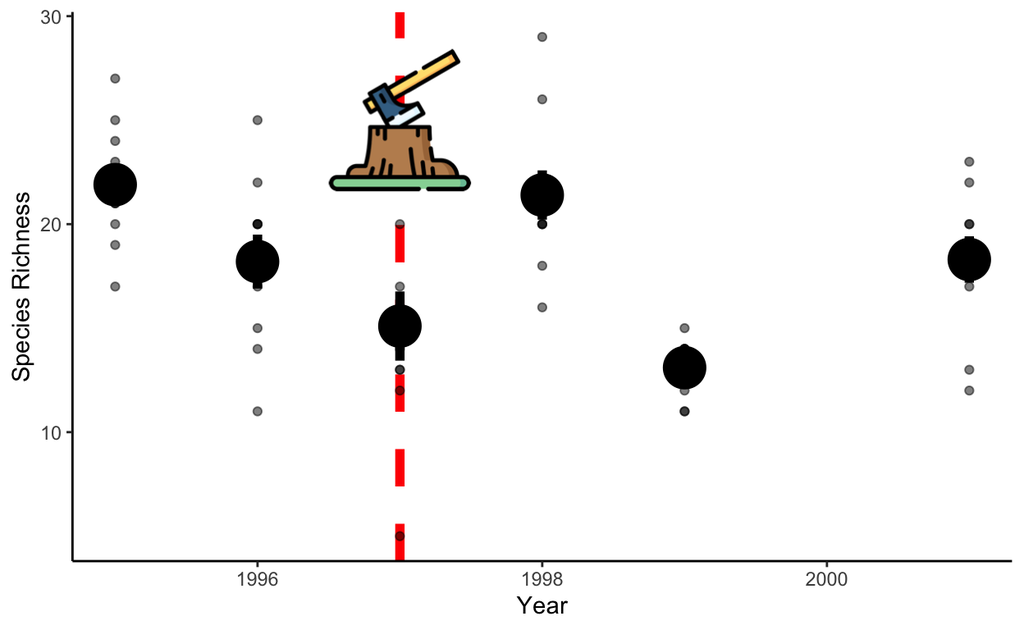

Figure 11: Species richness of aquatic macroinvertebrates over time. Each point is a replicate

```r
pacman::p_load(png, grid, ggplot2)
img <- readPNG("logging.png")
g <- rasterGrob(img, interpolate=TRUE)


ggplot()+
  geom_vline(xintercept=1997, linetype=2, color="red", size=2)+
  geom_point(richness_high, mapping=aes(x=year, y=richness), alpha=0.5)+
  geom_pointrange(richness_high, mapping=aes(x=year, y=richness), size=2, stat="summary")+
  theme_classic()+
  labs(y="Species Richness", x="Year")+
   annotation_custom(g, xmin=1996.5, xmax=1997.5, ymin=20, ymax=30)
```

Here is a plot of species richness, with a different value for each replicate. The red line is the year that the streams were logged. Do you see any change? Do you think there are any significant patterns? How does the variability between replicates compare to the variability between years?

#### Plot species evenness

We can also plot species evenness over time.

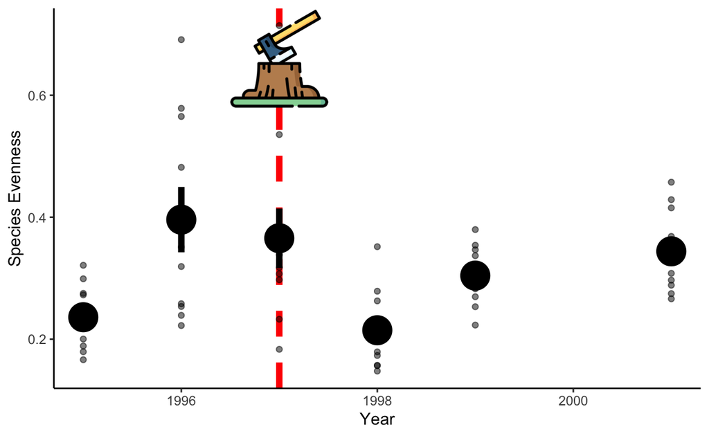

Figure 12: Species evenness of aquatic macroinvertebrates over time. Each point is a replicate

```r
ggplot()+
  geom_vline(xintercept=1997, linetype=2, color="red", size=2)+
  geom_point(richness_high, mapping=aes(x=year, y=SimpsonEvenness), alpha=0.5)+
  geom_pointrange(richness_high, mapping=aes(x=year, y=SimpsonEvenness), size=2, stat="summary")+
  theme_classic()+
  labs(y="Species Evenness", x="Year")+
   annotation_custom(g, xmin=1996.5, xmax=1997.5, ymin=0.57, ymax=0.75)
```

Do you see any patterns in the evenness between years?

## Using `community_diversity()`

Species richness and evenness are very simple ways to look at species diversity. However, as you learned from the rank abundance curves, species have different abundances within the community, with some species having very high abundance and most species having low abundance. Species richness does not take into account the relative abundances of each species, which limits the inferences we can make. The Shannon-Weiner diversity metric does take into account these relative abundances when calculating the diversity of a community and allows us to make more meaningful inferences about how biodiversity is changing over time.

## Shannon diversity with `community_diversity()`

The `codyn` package allows you to calculate the Shannon diversity index for a single site over time using the `community_diversity()` function. We will again use the data from the stream with the high logging intensity. Luckily, this function has the exact same syntax as the `community_structure()` function! The only difference is that the options for the `metric` argument are `Shannon` and `InverseSimpson`.

We will first use `Shannon`.

```r
shannon_div_high<-
  community_diversity(
    df=subset_codyn_high,
    time.var="year",
    abundance.var="abundance",
    replicate.var="replicate",
    metric="Shannon")
```

Let’s take a look at the output for this function.

```r
head(shannon_div_high)
```

```
  year replicate  Shannon
1 1995         1 1.836002
2 1996         1 2.044210
3 1997         1 2.107977
4 1998         1 2.016146
5 1999         1 1.948510
6 2001         1 2.297970
```

You can see it gives us a data frame of `year`, `replicate`, and `Shannon`, which is our measure of Shannon diversity.

## Plot Shannon’s diversity

[figure not shown]

Figure 13: Shannon’s diversity of aquatic macroinvertebrates over time. Each point is a replicate.

```r
ggplot()+
  geom_vline(xintercept=1997, linetype=2, color="red", size=2)+
  geom_point(shannon_div_high, mapping=aes(x=year, y=Shannon), alpha=0.5)+
  geom_pointrange(shannon_div_high, mapping=aes(x=year, y=Shannon), size=2, stat="summary")+
  theme_classic()+
  labs(y="Shannon Diversity", x="Year")+
   annotation_custom(g, xmin=1996.25, xmax=1997.75, ymin=2.22, ymax=2.5)
```

## Simpon’s diversity with `community_diversity`

We can also use the same function to calculate Simpson’s diversity by simply changing the `metric` argument to `InverseSimpson`.

```r
simpson_div_high <-
  community_diversity(
    df=subset_codyn_high,
    time.var="year",
    abundance.var="abundance",
    replicate.var="replicate",
    metric="InverseSimpson")
```

We can look at the output.

```r
head(simpson_div_high)
```

```
  year replicate InverseSimpson
1 1995         1       3.757421
2 1996         1       6.364238
3 1997         1       5.498534
4 1998         1       5.016063
5 1999         1       5.310341
6 2001         1       6.122265
```

## Plot Simpson’s diversity

And then plot.

[figure not shown]

Figure 14: Simpson’s diversity of aquatic macroinvertebrates over time. Each point is a replicate

```r
ggplot()+
  geom_vline(xintercept=1997, linetype=2, color="red", size=2)+
  geom_point(simpson_div_high, mapping=aes(x=year, y=InverseSimpson), alpha=0.5)+
  geom_pointrange(simpson_div_high, mapping=aes(x=year, y=InverseSimpson), size=2, stat="summary")+
  theme_classic()+
  labs(y="Simpson Diversity", x="Year")+
   annotation_custom(g, xmin=1996.5, xmax=1997.5, ymin=8, ymax=10)
```

How do these patterns compare to the patterns of Shannon’s diversity over time? How do the values compare?

## Activity

Calculate richness, evenness, and diversity using both the Shannon and Simpson indices for the streams with low intensity logging, high intensity logging, and no logging. The data for these streams are `subset_codyn_low`, `subset_codyn_high`, and `subset_codyn_ctrl`. Plot these indices. Do you see any patterns across years? How do these compare to the patterns in the high intensity logging stream?

EPA. 2022. “Indicators: Benthic Macroinvertebrates.” October 17, 2022. https://www.epa.gov/national-aquatic-resource-surveys/indicators-benthic-macroinvertebrates.

GBIF.org. 2022. “GBIF Home Page.” October 17, 2022. https://www.gbif.org.

Hallett, Lauren M., Sydney K. Jones, A. Andrew M. MacDonald, Matthew B. Jones, Dan F. B. Flynn, Julie Ripplinger, Peter Slaughter, Corinna Gries, and Scott L. Collins. 2016. “Codyn : An R Package of Community Dynamics Metrics.” Edited by Timothée Poisot. *Methods in Ecology and Evolution* 7 (10): 1146–51. https://doi.org/10.1111/2041-210x.12569.

Loreau, M., S. Naeem, P. Inchausti, J. Bengtsson, J. P. Grime, A. Hector, D. U. Hooper, et al. 2001. “Biodiversity and Ecosystem Functioning: Current Knowledge and Future Challenges.” *Science* 294 (5543): 804–8. https://doi.org/10.1126/science.1064088.

MacDonald, Zachary G., Scott E. Nielsen, and John H. Acorn. 2016. “Negative Relationships Between Species Richness and Evenness Render Common Diversity Indices Inadequate for Assessing Long-Term Trends in Butterfly Diversity.” *Biodiversity and Conservation* 26 (3): 617–29. https://doi.org/10.1007/s10531-016-1261-0.

RDocumentation. 2022. “Radfit: Rank – Abundance or Dominance / Diversity Models.” October 17, 2022. https://www.rdocumentation.org/packages/vegan/versions/2.4-2/topics/radfit.